# Bacias Hidrográficas: Análise e Gestão

Análise Ambiental · Aula 7.1

Prof. Dr. Luiz Diego Vidal Santos

## Abertura Visão Geral da Aula

Roteiro da aula Tópicos estruturantes

- 1 Bacia e microbacia hidrográfica: divisores, balanço hídrico e recorte legal
- 2 Hierarquia Fluvial de Horton-Strahler e Padrões de Drenagem (Christofoletti, 1980)
- 3 Equações e Índices Morfométricos ($K_c, K_f, I_c, D_d, D_h, t_c$) e propensão a cheias
- 4 Hidrograma de Enchente ($Q \times t$) e efeito do uso e cobertura da terra
- 5 Conectividade hidrossedimentológica e funções eco-hidrológicas da Zona Ripária
- 6 Política Nacional de Recursos Hídricos (Lei 9.433/1997): fundamentos, os 5 instrumentos e SINGREH

Objetivo da aula Análise e governança da água

Operar a **bacia hidrográfica** como unidade fundamental de análise ambiental e gestão territorial (Lei 9.433/1997), calculando seus parâmetros morfométricos, interpretando sua resposta hidrossedimentológica frente à mudança de uso da terra e aplicando os instrumentos da Política Nacional de Recursos Hídricos.

Strahler Morfometria Conectividade Lei 9.433/97

# A Bacia como Sistema Aberto e Unidade Legal

## Bacia Conceito Geomorfológico e Balanço Hídrico

Definição sistêmica Christofoletti (1980) · Tucci (2001)

Área de captação natural da água precipitada que faz convergir os escoamentos superficiais e subsuperficiais para um único ponto de saída (**exutório**), delimitada pelos **divisores topográficos (linhas de cumeada / interflúvios)**.

Atenção técnica · Bahia Divisor topográfico ≠ divisor freático

Em terrenos cársticos (calcários, como na Bacia do Rio São Francisco / **Irecê – BA**) ou sedimentares profundos (**Aquífero Urucuia**), o **divisor hidrogeológico** pode não coincidir com o divisor topográfico superficial!

**Equação do Balanço Hídrico na Bacia:**

$$P = Q_s + Q_b + ET \pm \Delta S$$

onde $P$ é a precipitação, $Q_s$ o escoamento superficial direto, $Q_b$ o escoamento básico (subterrâneo), $ET$ a evapotranspiração real e $\Delta S$ a variação do armazenamento no solo e no aquífero.

## Escalas Bacia, Sub-bacia e Microbacia

| Recorte | Escala Espacial Típica | Aplicação Principal |
| --- | --- | --- |
| **Região / Bacia Hidrográfica** | $> 10.000\text{ km}^2$ (ex.: Rio Paraguaçu, Rio São Francisco, Rio Contas) | Planos de Recursos Hídricos, Comitês de Bacia (CBH) e outorgas regionais. |
| **Sub-bacia** | $100\text{ a }10.000\text{ km}^2$ (ex.: Rio Jacuípe, Rio Subaé, Rio Pojuca) | Zoneamento ambiental intermunicipal, enquadramento CONAMA 357 e AII de EIA. |
| **Microbacia (Bacia de Cabeceira)** | $< 100\text{ km}^2$ (canais de 1ª a 3ª ordem; unidade ecológica mínima — Botelho, 1999) | Manejo integrado de solo e água, PRAD, monitoramento hidrossedimentológico e PSA. |

A escolha do recorte espacial define os processos observáveis: a **microbacia** captura a conexão direta vertente–canal; a **bacia** articula o planejamento regional e os comitês.

## Drenagem Delimitação da Bacia e Hierarquia de Strahler

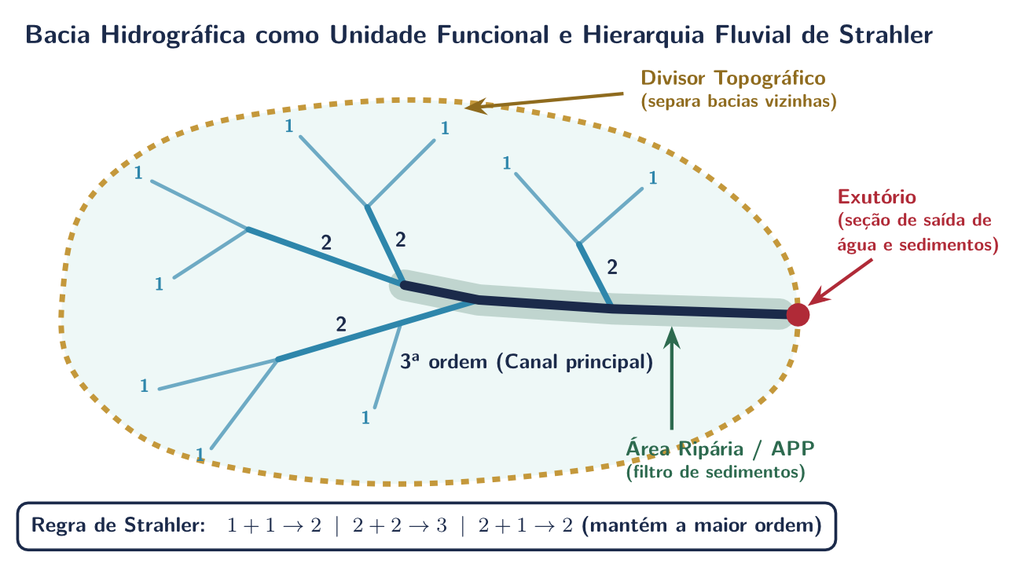

Delimitação da bacia hidrográfica pelo divisor topográfico até o exutório, com ordenamento fluvial segundo a hierarquia de Strahler e faixa ripária/APP.

Bacia hidrográfica como unidade funcional e hierarquia fluvial de Strahler (1952) Elaboração própria (TikZ) · divisor topográfico, canais de 1ª a 3ª ordem, área ripária/APP e exutório

Na regra de Strahler, apenas a confluência de dois canais de **mesma ordem** eleva a hierarquia ($1+1 \rightarrow 2$; $2+2 \rightarrow 3$); tributários menores não alteram a ordem do canal receptor ($2+1 \rightarrow 2$).

# Rede de Drenagem e Morfometria

## Drenagem Regime Hidrológico e Ordem (Strahler, 1952)

Regime de escoamento Relação com o nível freático

- **Perene:** fluxo contínuo o ano todo (lençol freático alimenta o canal mesmo na estiagem).
- **Intermitente:** escoa na estação chuvosa e seca na estiagem (típico do Semiárido baiano — *protegido por APP na Lei 12.651/2012!*).
- **Efêmero:** escoa apenas durante ou logo após chuvas torrenciais (acima do nível freático).

Ordenamento fluvial Regras de Strahler (1952)

- Nascentes sem tributários = **1ª ordem**;
- $1\text{ª} + 1\text{ª} \rightarrow 2\text{ª ordem}$;
- $2\text{ª} + 2\text{ª} \rightarrow 3\text{ª ordem}$;
- Confluência de ordens diferentes **mantém a ordem maior** ($2\text{ª} + 1\text{ª} = 2\text{ª ordem}$).

## Drenagem Padrões de Drenagem e Controle Geológico

| Padrão | Geometria da Rede | Controle Litológico / Estrutural |
| --- | --- | --- |
| **Dendrítico** (Arborescente) | Ramificação irregular semelhante a uma árvore | Rochas de **resistência uniforme** (granitos, gnaisses homogêneos ou sedimentos horizontais). |
| **Treliça** | Tributários paralelos confluindo em ângulo reto ($\approx 90^\circ$) | Dobramentos ou faixas alternadas de rochas resistentes e friáveis (ex.: Chapada Diamantina). |
| **Retangular** | Inflexões bruscas em ângulo reto no canal principal e afluentes | Forte controle por **redes de falhas e fraturas ortogonais** em rochas cristalinas. |
| **Paralelo** | Cursos d’água paralelos entre si com poucos tributários | Vertentes de **acentuada declividade** uniforme ou controle estrutural monoclinal. |
| **Radial** | Canais divergem de um ponto central (centrífugo) ou convergem (centrípeto) | Domos estruturais, cones vulcânicos, maciços residuais (*inselbergs*) ou depressões fechadas. |

## Morfometria Morfometria: equações e unidades

$$K_c = \frac{0{,}28\,P}{\sqrt{A}} \qquad K_f = \frac{A}{L_a^2} \qquad I_c = \frac{4\pi A}{P^2} \qquad D_d = \frac{\sum L_i}{A} \qquad D_h = \frac{N}{A} \qquad t_c = 0{,}0195\,L^{0{,}77}\,S^{-0{,}385}$$

| Índice | Variáveis e Unidades | Interpretação Hidrológica |
| --- | --- | --- |
| **Compacidade ($K_c$)** | $P$ (km), $A$ (km²) | Aproximação da forma circular ($K_c \to 1{,}0$ maior concentração) |
| **Fator de forma ($K_f$)** e **Circularidade ($I_c$)** | $L_a$ axial (km); $I_c$ adimensional | Sensível à delimitação e ao perímetro; valores altos elevam tendência a picos |
| **Densidade de drenagem ($D_d$) e hidrográfica ($D_h$)** | $\text{km/km}^2$ e $\text{canais/km}^2$ | Depende da escala de extração da rede e do critério de contagem ($N$) |
| **Tempo de concentração ($t_c$ · Kirpich)** | min ($L$ em m; $S$ em m/m) | Relação empírica com domínio de aplicação definido |

A forma da bacia participa da resposta junto com chuva, umidade antecedente, infiltração, armazenamento e uso da terra.

## Prática Exercício morfométrico com controle de unidades

**Bacia didática:** área $A = 12\text{ km}^2$; perímetro $P = 16\text{ km}$; comprimento axial $L_a = 6\text{ km}$; rede com $\sum L_i = 24\text{ km}$ de canais.

- $K_c = 0{,}28(16)/\sqrt{12} \approx 1{,}29$ | $K_f = 12/6^2 \approx 0{,}33$
- $I_c = 4\pi(12)/16^2 \approx 0{,}59$ | $D_d = 24/12 = 2{,}0\text{ km/km}^2$

Limite da morfometria O que falta para estimar a cheia?

Esses números **não fornecem a vazão de cheia**. Indique quais dados de **chuva** (intensidade e duração), **solo** (infiltração e profundidade), **armazenamento** e **ocupação da terra** são indispensáveis para modelar o hidrograma.

## Hidrologia Hidrograma de Enchente e Uso da Terra

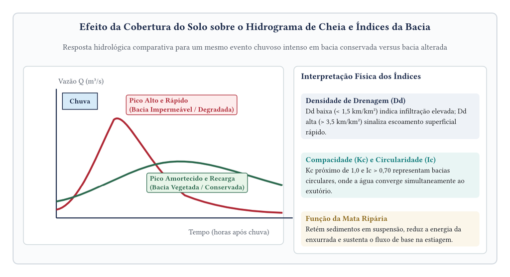

Hidrograma comparativo entre bacia impermeabilizada ou degradada e bacia conservada, articulado à interpretação física de Dd, Kc, Ic e mata ripária.

Efeito da cobertura do solo sobre o hidrograma de cheia e interpretação dos índices Elaboração própria (PGFPlots) · pico alto e rápido em bacia impermeável vs. pico amortecido e recarga em bacia vegetada

A perda de cobertura vegetal e a impermeabilização reduzem a infiltração e o tempo de concentração ($t_c$), antecipando e elevando a vazão de pico ($Q_p$).

## Hidrologia Ler um hidrograma e reconhecer seus limites

Identifique **início da resposta**, **ramo ascendente**, **pico**, **recessão** e **vazão anterior**.

**01 · Tempo de resposta:** relacione os horários da chuva intensa e do pico no exutório.

**02 · Umidade antecedente:** compare eventos com precipitação semelhante e umidade prévia distinta no solo.

**03 · Controles artificiais:** verifique se barragem, derivação ou extravasamento altera o registro hidrométrico.

**04 · Pico vs. volume:** diferencie vazão de pico ($\text{m}^3/\text{s}$) e volume total escoado ($\text{m}^3$).

Avaliar a resposta em rede evita soluções pontuais que apenas transferem o problema de inundação para jusante.

# Conectividade e Zona Ripária

## Conectividade Conectividade Lateral e Longitudinal (Borselli et al., 2008)

Vertente → Canal Conectividade Lateral

Grau de acoplamento pelo qual o escoamento e os sedimentos erodidos nas encostas conseguem atingir a calha fluvial.

Estradas rurais mal drenadas, sulcos de pastagem e supressão de mata ciliar atuam como **atalhos hidráulicos**, elevando drasticamente a entrega de sedimentos (*Sediment Delivery Ratio — SDR*).

Montante → Jusante Conectividade Longitudinal

Transporte de água, sedimentos, nutrientes e organismos ao longo da rede fluvial.

Barragens interrompem essa conectividade, retendo sedimentos no reservatório e provocando **erosão de margem por “água faminta” (*hungry water*)** a jusante.

## Zona Ripária Cinco Funções Eco-Hidrológicas da Zona Ripária (APP)

01 · Filtragem física Dissipação de energia

Rugosidade da serapilheira e raízes reduz a velocidade da enxurrada e retém sedimentos; eficiência varia com largura, declive e concentração do fluxo.

02 · Buffer Strip Tampão biogeoquímico

Absorção radicular e desnitrificação bacteriana removem nitrato ($\text{NO}_3^-$), fósforo ($\text{PO}_4^{3-}$) e agrotóxicos antes de atingirem o canal.

03 · Margens Estabilidade geotécnica

Raízes reforçam os barrancos fluviais contra desmoronamentos; o solapamento basal exige avaliação hidráulica própria.

04 · Microclima aquático Temperatura e Oxigênio Dissolvido

O sombreamento arbóreo mantém a temperatura da água mais baixa e o **Oxigênio Dissolvido (OD)** mais elevado para a biota aquática.

05 · Conectividade ecológica Corredor e zona hiporreica

Assegura fluxo gênico de fauna e flora ao longo da rede de drenagem e promove armazenamento e troca hídrica na zona hiporreica aluvial.

# Política Nacional de Recursos Hídricos

## Lei 9.433/97 Os 6 Fundamentos da PNRH (Art. 1º)

Fundamento I Domínio público

A água é um **bem de domínio público** (União ou Estados — não existe água privada desde a CF/88).

Fundamento II Valor econômico

A água é um **recurso natural limitado, dotado de valor econômico**.

Fundamento III Uso prioritário na escassez

Em situações de escassez, a prioridade absoluta é o **consumo humano e a dessedentação de animais**.

Fundamento IV Uso múltiplo

A gestão dos recursos hídricos deve sempre proporcionar o **uso múltiplo das águas**.

Fundamento V Unidade territorial

A **bacia hidrográfica é a unidade territorial** para implementação da PNRH e atuação do SINGREH.

Fundamento VI Gestão descentralizada

Participação do Poder Público, usuários e comunidades (**gestão tripartite nos Comitês de Bacia**).

## Lei 9.433/97 Os 5 Instrumentos da PNRH (Art. 5º)

| Instrumento (Art. 5º) | Função Técnica na Gestão da Bacia |
| --- | --- |
| **I. Planos de Recursos Hídricos** | Planos diretores de longo prazo (por bacia, estado e país) com diagnóstico, balanço disponibilidade $\times$ demanda e metas. |
| **II. Enquadramento dos corpos de água em classes** | Estabelece a meta de qualidade da água (Classes Especial a 4 — **CONAMA 357/2005**) segundo os usos preponderantes pretendidos. |
| **III. Outorga dos direitos de uso** | Ato administrativo (**ANA** ou **INEMA-BA**) que autoriza captação superficial/subterrânea ou lançamento de efluentes por prazo determinado. |
| **IV. Cobrança pelo uso de recursos hídricos** | Reconhece a água como bem econômico, induz o uso racional e financia programas previstos no Plano de Bacia. |
| **V. Sistema de Informações (SNIRH)** | Coleta, tratamento, armazenamento e disponibilização pública de dados hidrometeorológicos e de outorgas. |

## Gestão Hídrica Convivência com o Semiárido e Gestão Hídrica Descentralizada

Segurança hídrica comunitária Captação pluvial e convivência com o Semiárido

Em bacias do Semiárido com **rios intermitentes** e forte déficit hídrico sazonal, a gestão integrada combina planejamento por bacia (Lei 9.433/1997) com tecnologias sociais descentralizadas, como as **cisternas de placas** (P1MC/ASA).

Essas estruturas reservam água da chuva para atravessar a estiagem, efetivando na prática o **uso prioritário de consumo humano** (Art. 1º, III).

Governança territorial Da propriedade ao SINGREH

A reserva descentralizada nas comunidades rurais articula-se aos **Comitês de Bacia Hidrográfica (CBHs)** e à gestão estadual (**INEMA-BA**) para reduzir conflitos de escassez e proteger nascentes e áreas de recarga.

[figure not shown]

Cisterna de placas rurais no Semiárido vinculada ao Programa Um Milhão de Cisternas (P1MC / ASA).

Cisterna de placas no Semiárido (P1MC / ASA) Infraestrutura social de captação pluvial para segurança hídrica na estiagem

# Síntese e Referências

## Síntese Resumo para Provas e Relatório Técnico

01 · Forma e resposta Morfometria da bacia

**Bacias circulares** ($K_c \to 1{,}0$, $K_f$ alto, $I_c \to 1{,}0$) concentram o escoamento simultaneamente e têm resposta potencialmente mais concentrada, dependente também de chuva, armazenamento e uso da terra.

02 · Mudança de uso Desmatamento e urbanização

Reduzem a infiltração ($f$) e o tempo de concentração ($t_c$), podendo antecipar e elevar a **vazão de pico ($Q_p$)**; efeitos sobre a vazão de base dependem do balanço hídrico e da hidrogeologia.

03 · Marco legal Lei Federal nº 9.433/1997

A **bacia hidrográfica** deixa de ser apenas um recorte geomorfológico e torna-se a **unidade legal obrigatória de planejamento e gestão tripartite** no SINGREH.

## Referências Referências Bibliográficas

Legislação e manejo de bacias Fontes normativas e aplicadas

- BOTELHO, R. G. M. Planejamento ambiental em microbacia hidrográfica. In: GUERRA, A. J. T.; SILVA, A. S.; BOTELHO, R. G. M. (Orgs.). **Erosão e Conservação dos Solos**. Rio de Janeiro: Bertrand Brasil, 1999. p. 269–300.
- BRASIL. **Lei nº 9.433, de 8 de janeiro de 1997** (Política Nacional de Recursos Hídricos — PNRH).
- VILLELA, S. M.; MATTOS, A. **Hidrologia Aplicada**. São Paulo: McGraw-Hill do Brasil, 1975.

Geomorfologia fluvial e hidrologia Fundamentos clássicos

- CHRISTOFOLETTI, A. **Geomorfologia**. 2. ed. São Paulo: Edgard Blücher, 1980.
- STRAHLER, A. N. Hypsometric (area-altitude) analysis of erosional topography. **Geological Society of America Bulletin**, v. 63, p. 1117–1142, 1952.
- TUCCI, C. E. M. (Org.). **Hidrologia: ciência e aplicação**. 2. ed. Porto Alegre: Editora da UFRGS; ABRH, 2001.